# Climate Farmers coding challenge

Maria Voigt

20. November 2023

[figure not shown]

Coding challenge for Climate Farmers

# 1 Region Selection and Data Aqcuisition

## 1.1 Region selection and basemap preparation

I decided to work with Portugal, because it includes various types of landcover, and has variability in soil organic carbon and climate. I imported the country shape from the gadm database [GADM database](https://gadm.org/download_country.html). As I want to work with mainland Portugal, I excluded Madeira and the Azores.

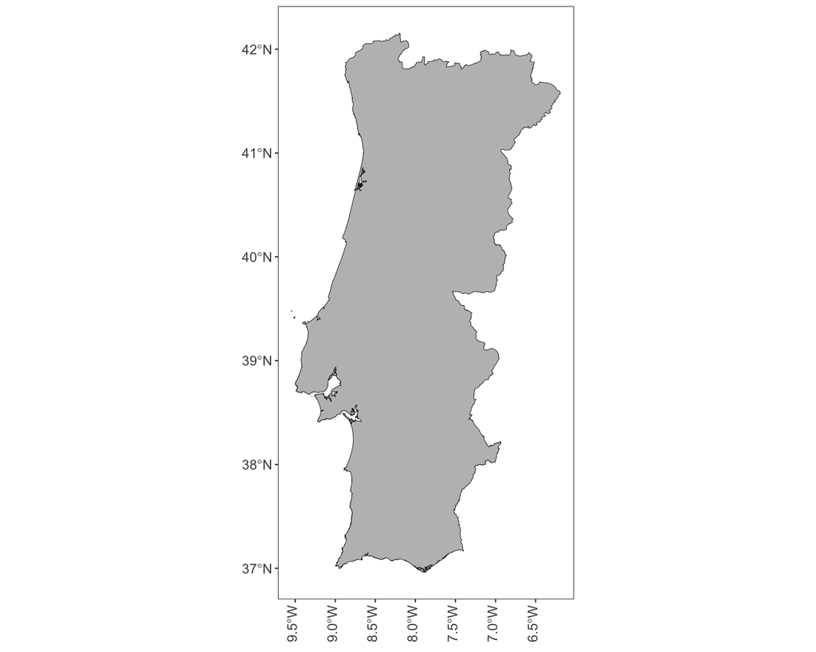

Shape of mainland Portugal used to restrict the analysis of soil, landcover and climate data.

## 1.2 Data Aqcuisition

I downloaded the following datasets for the analysis:

1. **Climate (years 2020-2022):**
   - *Temperature (unit: Kelvin):*  
     Air temperature 2 meters above land or water surfaces.
   - *Evapotranspiration (unit: Meters):*  
     Accumulated amount of water that has evaporated from the Earth’s surface, including a simplified representation of transpiration from vegetation.
   - *Precipitation (unit: Meters):*  
     Accumulated liquid and frozen water (rain, snow) falling to Earth’s surface, excluding fog, dew, and evaporated precipitation. It is the depth the water would have if it were spread evenly over the grid box.
2. **Landcover (year 2020):**
   - *Global gridded land cover classification:*  
     Land cover class per pixel, according to a legend of 22 classes, defined using the Land Cover Classification System developed by the United Nations Food and Agriculture Organization.
3. **Soil organic carbon (SOC):**
   - *Soil organic carbon (unit: t/ha):*  
     Soil organic carbon content in 0-30 cm depth.

### 1.2.1 Temperature

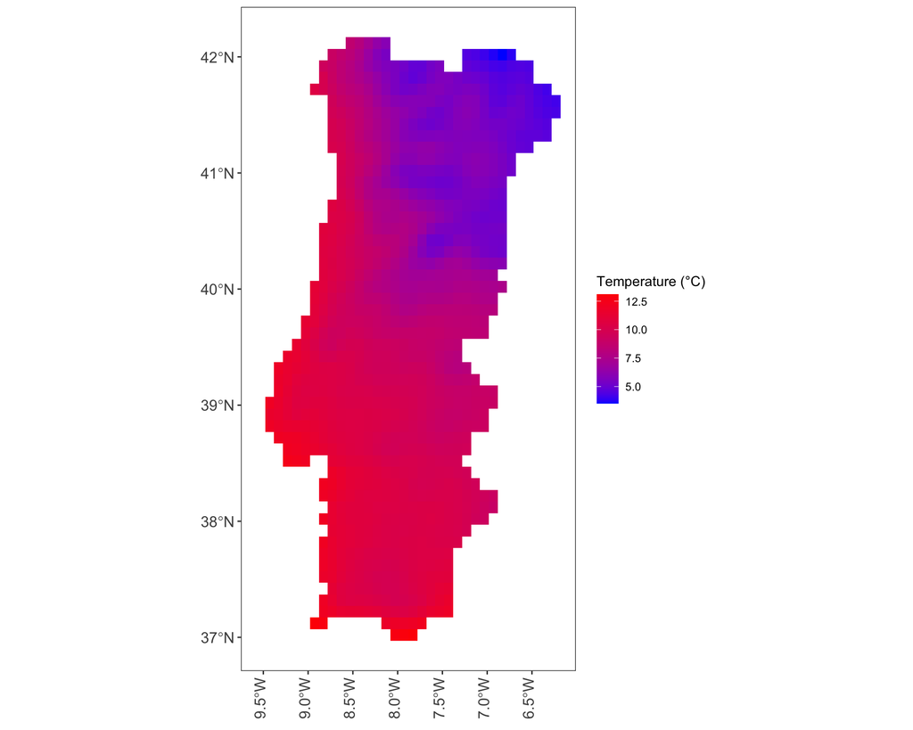

Temperature in Portugal for January 2020.

### 1.2.2 Evapotranspiration

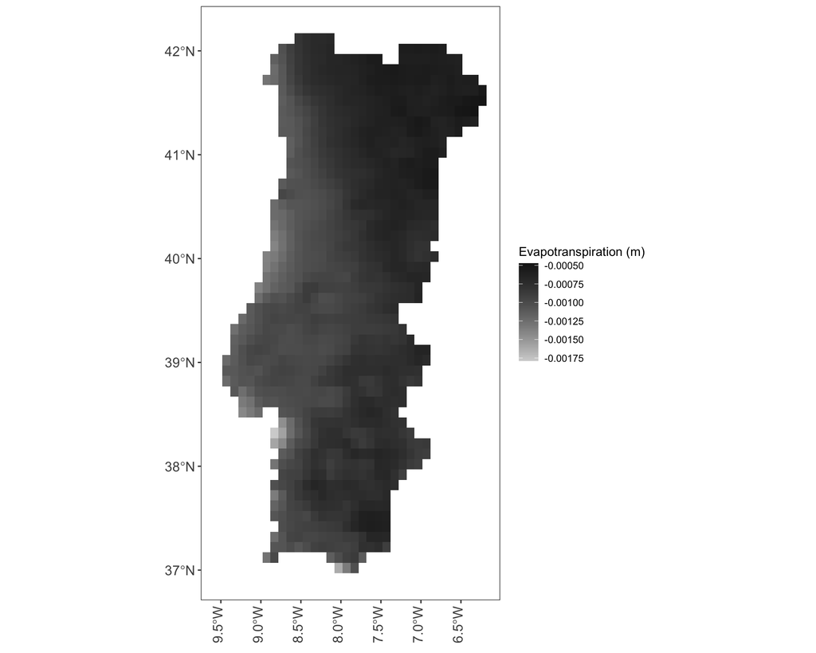

Evapotranspiration in Portugal for January 2020.

### 1.2.3 Precipitation

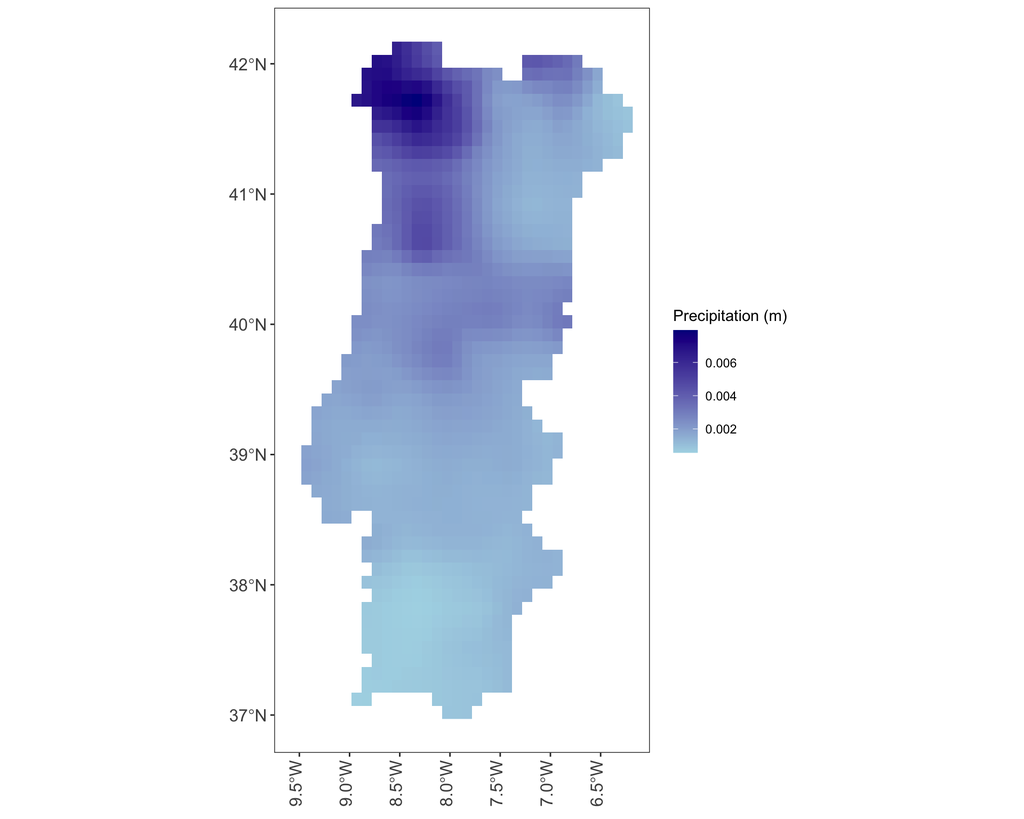

Precipitation in Portugal for January 2020.